# Finance Data Project

In this data project we will focus on Data Wrangling and EDA of stock prices for data trading dataset by daytrader.ai, https://www.kaggle.com/daytrader/ema-65-crossover

Link to Github repo for this file: https://github.com/gaurav214/Udacity-DataScience

Link to blog post for this project: https://medium.com/@negi.gaurav2/stock-price-analysis-afc61ebdcde1

# This project will include an analysis of best stocks for day trading

The NASDAQ stock market is an American stock exchange. It is the second largest exchange in the world by market capitalization, behind only New York Stock Exchange located in the same city. The exchange platform is owned by Nasdaq.Inc

[output not shown]

## Importing Libraries

```python
import numpy as np
import pandas as pd
import glob
import dateutil.parser
import csv
import os
from functools import reduce
import seaborn as sns
import datetime
import matplotlib.pyplot as plt
%matplotlib inline
```

### The following piece of code will combine the data of similar companies from more than 17,000 csv files

```python
def combine_data(indir,outfile,company):
    """
    The following code will combine all the data from the files in the folder for similar companies.

    Parameters:
    indir: Input directory
    outfile: Output directory

    """
    os.chdir(indir)
    filelist = glob.glob(company)
    dflist = []
    colnames = ['ISO formatted date', 'closing price', 'volume']
    for filename in filelist:
#        print(filename)
        df = pd.read_csv(filename,header = None)
        dflist.append(df)


    concatDf = pd.concat(dflist,axis=0)
    concatDf.columns = colnames
    concatDf.to_csv(outfile,index =None)
```

## We have a lot of files for each company and it will be difficult to analyze in this format so let's combine the files for similar companies

```python
data_dir_in = r'C:\Users\AAKASH\JUPYTER NOTEBOOKS\daytrader.ai\EMA-CROSSOVER'
data_dir_out = r'C:\Users\AAKASH\JUPYTER NOTEBOOKS\daytrader.ai\Outfiles' + r'\\'
```

```python
newfile_write = ['Netflix_newfile.csv','Baidu_newfile.csv', 'Microsoft_newfile.csv','Google_class_C_newfile.csv','Google_class_A_newfile.csv',
                'Tesla_newfile.csv', 'Adobe_newfile.csv','NVidia_newfile.csv', 'Amazon_newfile.csv', 'INTEL_newfile.csv','APPLE_newfile.csv',
                'FACEBOOK_newfile.csv']
company = ['*NFLX.csv','*BIDU.csv', '*MSFT.csv', '*GOOG.csv', '*GOOGL.csv', '*TSLA.csv', '*ADBE.csv', '*NVDA.csv',
          '*AMZN.csv', '*INTC.csv', '*AAPL.csv', '*FB.csv' ]
```

```python
for x,y in zip(newfile_write, company):

    combine_data(data_dir_in, data_dir_out + x, y)
```

```python
# This code will remove duplicates and arrange the price in ascending order
def remove_duplicates(filename,outfile):

    """
    The following code will remove all duplicate values and arrange the price in ascending order.

    Parameters:
    filename: Old file directory.
    outfile: New File directory.

    """

    df = pd.read_csv(filename)
    df.drop_duplicates(subset=['ISO formatted date'], keep='first', inplace=True)
    df = df.sort_values(by='ISO formatted date')
    df.to_csv(outfile,index = False)
```

```python
new_file_final = ['Netflix.csv','Baidu.csv','Microsoft.csv','Google_class_C.csv', 'Google_class_A.csv','Tesla.csv','Adobe.csv', 'NVidia.csv',
                  'Amazon.csv', 'INTEL.csv', 'Apple.csv' , 'FACEBOOK.csv']
```

```python
for x,y in zip(newfile_write,new_file_final):
    remove_duplicates(data_dir_out+x, data_dir_out+y)
```

### Making each csv file a dataframe

```python
df1 = pd.read_csv(data_dir_out + 'Adobe.csv')
df2 = pd.read_csv(data_dir_out + 'Amazon.csv')
df3 = pd.read_csv(data_dir_out + 'Apple.csv')
df4 = pd.read_csv(data_dir_out + 'Baidu.csv')
df5 = pd.read_csv(data_dir_out + 'FACEBOOK.csv')
df6 = pd.read_csv(data_dir_out + 'Google_class_A.csv')
df7 = pd.read_csv(data_dir_out + 'Google_class_C.csv')
df8 = pd.read_csv(data_dir_out + 'INTEL.csv')
df9 = pd.read_csv(data_dir_out + 'Microsoft.csv')
df10 = pd.read_csv(data_dir_out + 'Netflix.csv')
df11 = pd.read_csv(data_dir_out + 'NVidia.csv')
df12 = pd.read_csv(data_dir_out + 'Tesla.csv')
```

### Combining the dataframes into a single dataframe by using a inner join for similar datetimes

```python
dfs = [df1, df2, df3, df4, df5, df6, df7, df8, df9, df10, df11, df12]

company = reduce(lambda left,right: pd.merge(left,right,on='ISO formatted date'), dfs)
```

### Please note - In order to combine information for similar date and times a lot of information has been lost due to our inner join

```python
company.head()
```

|  | ISO formatted date | Adobe_closing price | volume_x | Amazon_closing price | volume_y | Apple_closing price | volume_x | Baidu_closing price | volume_y | FACEBOOK_closing price | ... | INTEL_closing price | volume_y | Microsoft_closing price | volume_x | Netflix_closing price | volume_y | Nvidia_closing price | volume_x | Tesla_closing price | volume_y |
| --- | --- | --- | --- | --- | --- | --- | --- | --- | --- | --- | --- | --- | --- | --- | --- | --- | --- | --- | --- | --- | --- |
| 0 | 2014-04-07T16:36:00.000Z | 60.26 | 7669 | 316.700 | 17115 | 70.0904 | 72316.9 | 143.85 | 14083 | 56.3600 | ... | 23.9699 | 34623.1 | 36.5370 | 37721.8 | 48.5285 | 42665.0 | 17.5451 | 1043.31 | 207.500 | 11130 |
| 1 | 2014-04-07T16:37:00.000Z | 60.32 | 12326 | 317.130 | 9379 | 70.0957 | 135458.0 | 143.90 | 16702 | 56.4400 | ... | 23.9744 | 57674.3 | 36.5370 | 49016.7 | 48.6914 | 173803.0 | 17.5643 | 8613.55 | 207.830 | 10013 |
| 2 | 2014-04-07T16:38:00.000Z | 60.33 | 3896 | 317.380 | 9488 | 70.0904 | 43921.1 | 143.88 | 7319 | 56.4200 | ... | 23.9924 | 115497.0 | 36.5461 | 27239.3 | 48.7142 | 48951.1 | 17.5691 | 11725.70 | 208.197 | 21402 |
| 3 | 2014-04-07T16:39:00.000Z | 60.30 | 10910 | 316.950 | 15176 | 70.0674 | 210220.0 | 143.96 | 36807 | 56.3499 | ... | 23.9564 | 137391.0 | 36.5233 | 58487.6 | 48.6157 | 124600.0 | 17.5691 | 20979.90 | 207.600 | 29252 |
| 4 | 2014-04-07T16:40:00.000Z | 60.34 | 10046 | 316.821 | 7916 | 70.0757 | 81201.4 | 143.94 | 9581 | 56.3800 | ... | 23.9699 | 35651.3 | 36.5233 | 56091.1 | 48.6428 | 32284.0 | 17.5835 | 11645.40 | 207.840 | 11709 |

5 rows × 25 columns

```python
stock_price = company[['ISO formatted date', 'Adobe_closing price','Amazon_closing price', 'Apple_closing price', 'Baidu_closing price', 'FACEBOOK_closing price',
        'Google_class_A_closing price', 'Google_class_C_closing price', 'INTEL_closing price', 'Microsoft_closing price',
       'Netflix_closing price', 'Nvidia_closing price', 'Tesla_closing price']]
```

### Changing the format of the datetime column

```python
def date_func(datestring):
    """
    The following code will change the format of the date function from string to date.

    Parameters:
    datestring: date in string.

    """

    return dateutil.parser.parse(datestring)
```

```python
stock_price['ISO formatted date'] = stock_price['ISO formatted date'].apply(lambda x: date_func(x))
```

```python
stock_price.set_index('ISO formatted date', inplace=True)
```

```python
stock_price.head()
```

| ISO formatted date | Adobe_closing price | Amazon_closing price | Apple_closing price | Baidu_closing price | FACEBOOK_closing price | Google_class_A_closing price | Google_class_C_closing price | INTEL_closing price | Microsoft_closing price | Netflix_closing price | Nvidia_closing price | Tesla_closing price |
| --- | --- | --- | --- | --- | --- | --- | --- | --- | --- | --- | --- | --- |
| 2014-04-07 16:36:00+00:00 | 60.26 | 316.700 | 70.0904 | 143.85 | 56.3600 | 534.16 | 529.731 | 23.9699 | 36.5370 | 48.5285 | 17.5451 | 207.500 |
| 2014-04-07 16:37:00+00:00 | 60.32 | 317.130 | 70.0957 | 143.90 | 56.4400 | 534.45 | 530.069 | 23.9744 | 36.5370 | 48.6914 | 17.5643 | 207.830 |
| 2014-04-07 16:38:00+00:00 | 60.33 | 317.380 | 70.0904 | 143.88 | 56.4200 | 534.54 | 530.188 | 23.9924 | 36.5461 | 48.7142 | 17.5691 | 208.197 |
| 2014-04-07 16:39:00+00:00 | 60.30 | 316.950 | 70.0674 | 143.96 | 56.3499 | 534.08 | 529.728 | 23.9564 | 36.5233 | 48.6157 | 17.5691 | 207.600 |
| 2014-04-07 16:40:00+00:00 | 60.34 | 316.821 | 70.0757 | 143.94 | 56.3800 | 534.34 | 530.268 | 23.9699 | 36.5233 | 48.6428 | 17.5835 | 207.840 |

```python
sp = stock_price
```

## Finally, we have got our data in a single dataframe from more than 17,000 csv files as above dataframe named sp

# EDA

### Question 1: What is the maximum closing price of each stock?

**Business Understading:** The closing price is the final price at which a security is traded on a given trading day. The closing price represents the most up-to-date valuation of a security until trading commences again on the next trading day. Here we want to find at what time-stamp each company hit the maximum closing price of their stock.

**Data Understanding:** We have data of 12 companies stock price for over 3 years(2014 to 2017). The stock prices are stored every minute to get best granularity for our analysis. Initially we started with stock prices for each company and then denormalized all the companies stocks data into one data set. This helped in comparison between all stocks and improve our read performance.

**Data Preparation:** All the dataframes of companies were combined to a single dataset and then after combining all the stock prices of companies we did group by search for maximum closing price of each company and this what we observed.

**Results:**

**1. Maximum Closing Price for each stock**

```python
sp.max().sort_values()
```

```
INTEL_closing price               40.3785
Microsoft_closing price           78.9500
Apple_closing price              160.6150
Adobe_closing price              175.4000
FACEBOOK_closing price           176.6230
Nvidia_closing price             199.4200
Netflix_closing price            200.2430
Baidu_closing price              271.0700
Tesla_closing price              386.7800
Google_class_C_closing price     996.6000
Google_class_A_closing price    1015.8500
Amazon_closing price            1082.7600
dtype: float64
```

**2. Time stamp at which the closing price was maximum**

```python
sp.idxmax()
```

```
Adobe_closing price            2017-10-20 18:44:00+00:00
Amazon_closing price           2017-07-27 16:04:00+00:00
Apple_closing price            2017-10-18 13:37:00+00:00
Baidu_closing price            2017-10-17 17:02:00+00:00
FACEBOOK_closing price         2017-10-18 13:30:00+00:00
Google_class_A_closing price   2017-10-18 14:47:00+00:00
Google_class_C_closing price   2017-10-18 14:44:00+00:00
INTEL_closing price            2017-10-20 13:30:00+00:00
Microsoft_closing price        2017-10-20 18:03:00+00:00
Netflix_closing price          2017-10-17 19:03:00+00:00
Nvidia_closing price           2017-10-20 13:33:00+00:00
Tesla_closing price            2017-06-23 15:00:00+00:00
dtype: datetime64[ns, UTC]
```

### Question 2: Which stocks have highly correlated returns?

**Business Understanding:** In finance, return is a profit on an investment. It comprises any change in value of the investment, and/or cash flows which the investor receives from the investment, such as interest payments or dividends. It may be measured either in absolute terms (e.g., dollars) or as a percentage of the amount invested. Here we want to find the stocks that are highly correlated and might help a day trader to predict the behaviour of one stock by observing the behaviour of other stock.

**Data Understanding**:Our prepared data set include 13 columns with first column being the timestamp of a specific stock price and all other 12 columns represent the stock price of their respective company.

**Data Prepration:** We created a new empty DataFrame called returns. This dataframe will contain the returns for each stock. returns are typically defined by:**

$$r_t = \frac{p_t - p_{t-1}}{p_{t-1}} = \frac{p_t}{p_{t-1}} - 1$$

We also used pandas pct_change() method on the Close column to create a column representing this return value. Create a for loop that goes and for each Stock column and creates this returns column and set's it as a column in the returns DataFrame.

```python
returns = pd.DataFrame()
```

**We can use pandas pct_change() method on the Close column to create a column representing this return value. Create a for loop that goes and for each Stock column and creates this returns column and set's it as a column in the returns DataFrame.**

```python
stock_names = ['Adobe_closing price','Amazon_closing price', 'Apple_closing price', 'Baidu_closing price', 'FACEBOOK_closing price',
        'Google_class_A_closing price', 'Google_class_C_closing price', 'INTEL_closing price', 'Microsoft_closing price',
       'Netflix_closing price', 'Nvidia_closing price', 'Tesla_closing price']
```

```python
for t in stock_names:
    returns[t + ' Returns'] = sp[t].pct_change()
returns.head()
```

| ISO formatted date | Adobe_closing price Returns | Amazon_closing price Returns | Apple_closing price Returns | Baidu_closing price Returns | FACEBOOK_closing price Returns | Google_class_A_closing price Returns | Google_class_C_closing price Returns | INTEL_closing price Returns | Microsoft_closing price Returns | Netflix_closing price Returns | Nvidia_closing price Returns | Tesla_closing price Returns |
| --- | --- | --- | --- | --- | --- | --- | --- | --- | --- | --- | --- | --- |
| 2014-04-07 16:36:00+00:00 | NaN | NaN | NaN | NaN | NaN | NaN | NaN | NaN | NaN | NaN | NaN | NaN |
| 2014-04-07 16:37:00+00:00 | 0.000996 | 0.001358 | 0.000076 | 0.000348 | 0.001419 | 0.000543 | 0.000638 | 0.000188 | 0.000000 | 0.003357 | 0.001094 | 0.001590 |
| 2014-04-07 16:38:00+00:00 | 0.000166 | 0.000788 | -0.000076 | -0.000139 | -0.000354 | 0.000168 | 0.000224 | 0.000751 | 0.000249 | 0.000468 | 0.000273 | 0.001766 |
| 2014-04-07 16:39:00+00:00 | -0.000497 | -0.001355 | -0.000328 | 0.000556 | -0.001242 | -0.000861 | -0.000868 | -0.001500 | -0.000624 | -0.002022 | 0.000000 | -0.002867 |
| 2014-04-07 16:40:00+00:00 | 0.000663 | -0.000407 | 0.000118 | -0.000139 | 0.000534 | 0.000487 | 0.001019 | 0.000564 | 0.000000 | 0.000557 | 0.000820 | 0.001156 |

**Create a pairplot using seaborn of the returns dataframe. Which stocks stands out?**

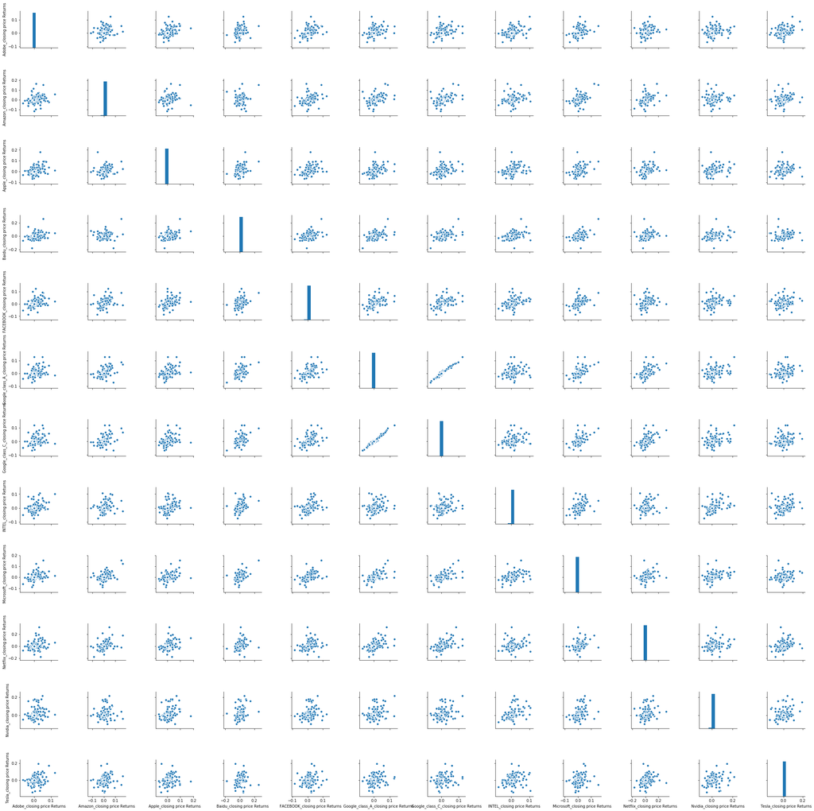

```python
sns.pairplot(returns[1:])
plt.figure(figsize=(35,35))
```

### Please zoom in to view the names of companies on x and y axis as it was not possible to show them easily or you can see them in the cluster map in the last section

```python
returns.idxmax()
```

```
Adobe_closing price Returns            2014-06-19 17:22:00+00:00
Amazon_closing price Returns           2015-04-24 16:59:00+00:00
Apple_closing price Returns            2014-05-27 14:26:00+00:00
Baidu_closing price Returns            2015-10-30 15:31:00+00:00
FACEBOOK_closing price Returns         2016-01-28 14:30:00+00:00
Google_class_A_closing price Returns   2017-05-10 17:04:00+00:00
Google_class_C_closing price Returns   2017-05-10 17:04:00+00:00
INTEL_closing price Returns            2014-12-08 15:33:00+00:00
Microsoft_closing price Returns        2015-10-30 15:31:00+00:00
Netflix_closing price Returns          2015-01-23 18:22:00+00:00
Nvidia_closing price Returns           2017-05-10 17:04:00+00:00
Tesla_closing price Returns            2017-06-19 17:59:00+00:00
dtype: datetime64[ns, UTC]
```

```python
returns.idxmin()
```

```
Adobe_closing price Returns            2015-08-27 18:04:00+00:00
Amazon_closing price Returns           2014-07-25 13:30:00+00:00
Apple_closing price Returns            2016-04-27 17:15:00+00:00
Baidu_closing price Returns            2015-07-29 16:35:00+00:00
FACEBOOK_closing price Returns         2016-11-10 17:17:00+00:00
Google_class_A_closing price Returns   2015-07-29 16:35:00+00:00
Google_class_C_closing price Returns   2015-07-29 16:35:00+00:00
INTEL_closing price Returns            2016-01-21 16:33:00+00:00
Microsoft_closing price Returns        2015-01-27 14:30:00+00:00
Netflix_closing price Returns          2014-10-27 17:35:00+00:00
Nvidia_closing price Returns           2017-03-01 18:58:00+00:00
Tesla_closing price Returns            2016-09-09 17:26:00+00:00
dtype: datetime64[ns, UTC]
```

### Question 3: Which stock would you classify as the riskiest over the entire time period?

**Business Understanding:**

The risk of the stock is determined by the how much the stock price varies within a period of time. Here we want to find out the company with very unstable price growth and the company which is the least riskiest to invest in. This use case will help a day trader to sort the stocks by their risk factor and help in making effective day trading strategies.

**Data Understanding:**

Standard deviation is a quantity expressing by how much the members of a group differ from the mean value for the group. In our dataset we are taking standard deviation of each company stock and then comparing them to determine which stocks differ by how much.

```python
# Take a look at the standard deviation of the returns
returns.std()
```

```
Adobe_closing price Returns             0.001222
Amazon_closing price Returns            0.001572
Apple_closing price Returns             0.001353
Baidu_closing price Returns             0.001907
FACEBOOK_closing price Returns          0.001339
Google_class_A_closing price Returns    0.001290
Google_class_C_closing price Returns    0.001261
INTEL_closing price Returns             0.001263
Microsoft_closing price Returns         0.001242
Netflix_closing price Returns           0.002457
Nvidia_closing price Returns            0.002182
Tesla_closing price Returns             0.002205
dtype: float64
```

**Results Evaluations:**

Netflix is the most risky stock as it has the highest standard deviation of 0.002457 and Adobe is the least risky stock with a standard deviation of 0.001222. Netflix has a gradually increasing but very fluctuating graph(high standard deviation) and Adobe with the most stable growth and least standard deviation. It is further explained using moving average graphs below.

**Distplot using seaborn of the returns for Netflix**

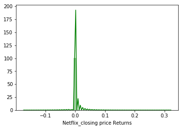

```python
sns.distplot(returns['Netflix_closing price Returns'][1:],color = 'green',bins =50)
```

# More Visualization

### Imports

```python
import matplotlib.pyplot as plt
import seaborn as sns
sns.set_style('whitegrid')
%matplotlib inline

# Optional Plotly Method Imports
import plotly
import cufflinks as cf
cf.go_offline()
plotly.offline.init_notebook_mode(connected=True)
#plt.offline.init_notebook_mode(connected=True)
```

**A line plot showing Close price for each stock for the entire index of time.**

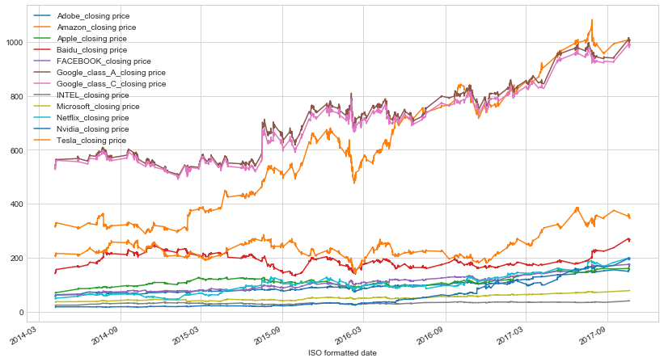

```python
sp.plot(figsize = (14,8))
```

### Interactive plot of stock prices for 2016

```python
## Please note that I did not ran the following piece of code as it was increasing the file size to more than 25mb and
## I could not have uploaded the file to github
# sp['2016-01-01':'2016-12-01'].iplot()
```

### Interactive plot of stock prices for 2017

```python
## Please note that I did not ran the following piece of code as it was increasing the file size to more than 25mb and
## I could not have uploaded the file to github
#sp['2017-01-01':'2017-06-01'].iplot()
```

## Moving Averages

Let's analyze the moving averages for these stocks for the year 2016 and 2017.

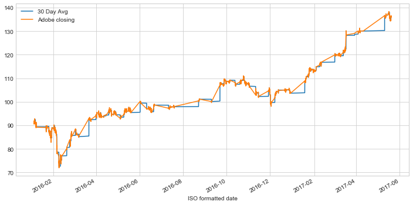

```python
plt.figure(figsize=(12,6))
sp['Adobe_closing price'].loc['2016-01-01':'2017-06-01'].rolling(window=30).mean().plot(label='30 Day Avg')
sp['Adobe_closing price'].loc['2016-01-01':'2017-06-01'].plot(label='Adobe closing')
plt.legend()
```

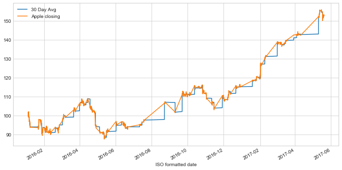

```python
plt.figure(figsize=(12,6))
sp['Apple_closing price'].loc['2016-01-01':'2017-06-01'].rolling(window=30).mean().plot(label='30 Day Avg')
sp['Apple_closing price'].loc['2016-01-01':'2017-06-01'].plot(label='Apple closing')
plt.legend()
```

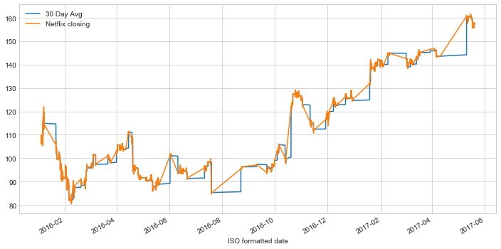

```python
plt.figure(figsize=(12,6))
sp['Netflix_closing price'].loc['2016-01-01':'2017-06-01'].rolling(window=30).mean().plot(label='30 Day Avg')
sp['Netflix_closing price'].loc['2016-01-01':'2017-06-01'].plot(label='Netflix closing')
plt.legend()
```

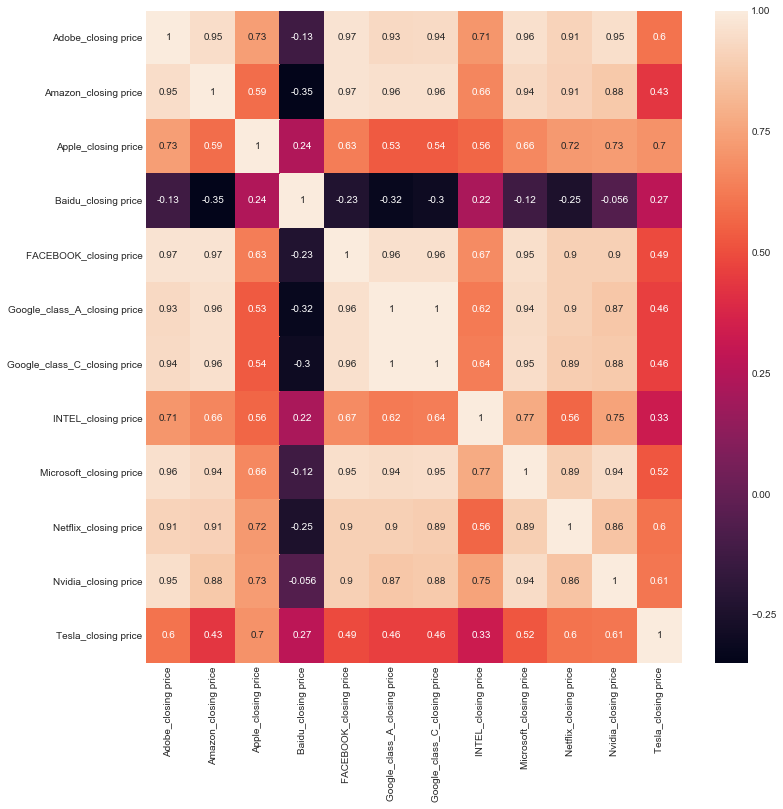

```python
plt.subplots(figsize=(12,12))
sns.heatmap(sp.corr(),annot=True)
```

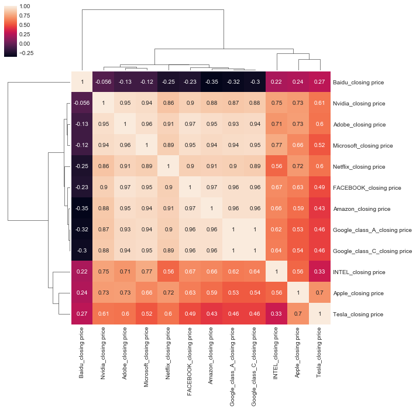

```python
plt.figure(figsize=(12,12))
sns.clustermap(sp.corr(),annot=True);
```

### As we can see here the stocks with highest level of correlation are grouped together that is NVidia, Adobe, Microsoft, Netflix, Facebook, Amazon, Google class A and Google class C.

**Creating a Simple Moving Averages plot of Netflix for the year 2016.**

```python
## Please note that I did not ran the following piece of code as it was increasing the file size to more than 25mb and
## I could not have uploaded the file to github

#sp['Netflix_closing price'].loc['2016-01-01':'2016-12-30'].ta_plot(study='sma',periods=[13,21,55],title='Simple Moving Averages')
```